# Fitcoach package workflow example

Niraj Juneja, Charles de L

## Example 1: Data Loader - Getting data from Fitbit API

This part explains how to connect to the Fitbit API and get your data, using `DataLoader`.

**Step 1:** You first need to make sure that you have [registered an app](https://dev.fitbit.com/) and set it as *Personal* in order to retrieve intraday data. You will need the following credentials in order to connect the API: App name (or *OAuth 2.0 Client ID*), Client Key and Client Secret.

**Step 2:** We initialize a new `DataLoader` object, and connect to the API with OAuth2, using the credentials described above. Note that instead of providing the credentials directly as parameters, you could point to a cache file (usually named `.httr-oauth`) using the `cache.file` parameter.

```r
mydata <- DataLoader$new()
mydata$connect(appname = "cdlr",
               key = "227FWR",
               secret = "3089e3d1ac5dde1aa00b54a0c8661f42"
)
```

**Step 3:** We request the data and write it to JSON files using the `request` method. You need to specify the type of timeseries (‘day’ or ‘intraday’), the list of activities ([full list here](https://dev.fitbit.com/docs/activity/)), the start and end dates, and the folder in which the JSON files will be written.

```r
masterPath <- system.file("extdata",
                          "daily-time-series",
                          package = "fitcoach")

mydata$request(
    type = 'day',
    activities = list("calories", "steps", "distance", "minutesVeryActive"),
    start.date = "2016-01-01",
    end.date = "2016-02-01",
    path = masterPath
)
```

Once the JSON files have been created, they can be used for further analysis.

## Example 2: Fit Analyzer - Daily File Analysis

Examples below demonstrate usage scenarios for `FitAnalyzer`.

**Step 1:** We first need to point to a folder that contains the JSON files for “daily” file analysis. These files are created by `DataLoader.R`.

We then create a new instance of `FitAnalyzer`, passing in the folder and the goal that we want to optimize on. Goals can be the following: a) calories b) steps c) distance d) floors.

The example below uses `steps` as the goal.

```r
masterPath <- system.file("extdata",
                          "daily-time-series",
                          package = "fitcoach")

ana <- FitAnalyzer$new("steps")
```

**Step 2:** Next we get the data.frame ready for analysis. Note this data.frame is cleaned and augmented with additional data elements not present in the JSON file. E.g.: we augment `weekday`, `weekend` and mark rows that are valid.

```r
timeseries.frame <-
    ana$getAnalysisFrame(folder = masterPath,
                         analysis.type = "daily")
head(timeseries.frame)
```

```
##           date calories caloriesBMR steps distance floors elevation
## 898 2015-07-31     1867        1759   195  0.14062      0         0
## 899 2015-08-01     3245        1758 12866 10.44119     13        39
## 900 2015-08-02     2867        1758  5023  3.65184     11        33
## 901 2015-08-03     2982        1758 10112  7.35157      6        18
## 902 2015-08-04     2734        1758  5725  4.16213      7        21
## 903 2015-08-05     3012        1758  9155  6.72913      5        15
##     minutesSedentary minutesLightlyActive minutesFairlyActive
## 898              205                   10                   0
## 899              672                  269                   5
## 900              691                  168                  25
## 901             1161                  143                   5
## 902              836                  150                  18
## 903              640                  267                  16
##     minutesVeryActive activityCalories valid   weekday weekend
## 898                 0               51  TRUE    Friday   FALSE
## 899                37             1600  TRUE  Saturday    TRUE
## 900                35             1196  TRUE    Sunday    TRUE
## 901                66             1253  TRUE    Monday   FALSE
## 902                23              961  TRUE   Tuesday   FALSE
## 903                16             1372  TRUE Wednesday   FALSE
```

**Step 3:** next we find the most important variables that are enabling meeting the goals for the person. Note this call creates a `glm` model behind the scenes and ranks the variables based on the coefficients of the glm model. You can also get the `glm` fit object to do further analysis.

```r
vars <- ana$findImportantVariables(tsDataFrame = timeseries.frame,
                                   seed = 12345)
vars
```

```
##      Overall                 name
## 1 83.7286565             distance
## 2  3.4383872 minutesLightlyActive
## 3  1.8757480               floors
## 4  1.8523923            elevation
## 5  1.2891208  minutesFairlyActive
## 6  1.1386025     minutesSedentary
## 7  1.1244243    minutesVeryActive
## 8  0.2122723              holiday
```

Getting the `fit` object.

```r
fit <- ana$getFit()
summary(fit)
```

```
##
## Call:
## glm(formula = y ~ ., family = "gaussian", data = x)
##
## Deviance Residuals:
##      Min        1Q    Median        3Q       Max
## -1192.03    -17.96     12.12     54.98    264.72
##
## Coefficients:
##                        Estimate Std. Error t value Pr(>|t|)
## (Intercept)           -83.72528   62.25542  -1.345 0.180342
## distance             1323.59328   15.80813  83.729  < 2e-16 ***
## floors               -472.34421  251.81645  -1.876 0.062291 .
## elevation             153.87808   83.06992   1.852 0.065589 .
## minutesSedentary        0.05395    0.04738   1.139 0.256365
## minutesLightlyActive    1.30032    0.37818   3.438 0.000725 ***
## minutesFairlyActive     1.70467    1.32235   1.289 0.198992
## minutesVeryActive       1.66153    1.47767   1.124 0.262314
## holiday                 5.05059   23.79298   0.212 0.832132
## ---
## Signif. codes:  0 '***' 0.001 '**' 0.01 '*' 0.05 '.' 0.1 ' ' 1
##
## (Dispersion parameter for gaussian family taken to be 18358.87)
##
##     Null deviance: 1752078977  on 190  degrees of freedom
## Residual deviance:    3341314  on 182  degrees of freedom
## AIC: 2428
##
## Number of Fisher Scoring iterations: 2
```

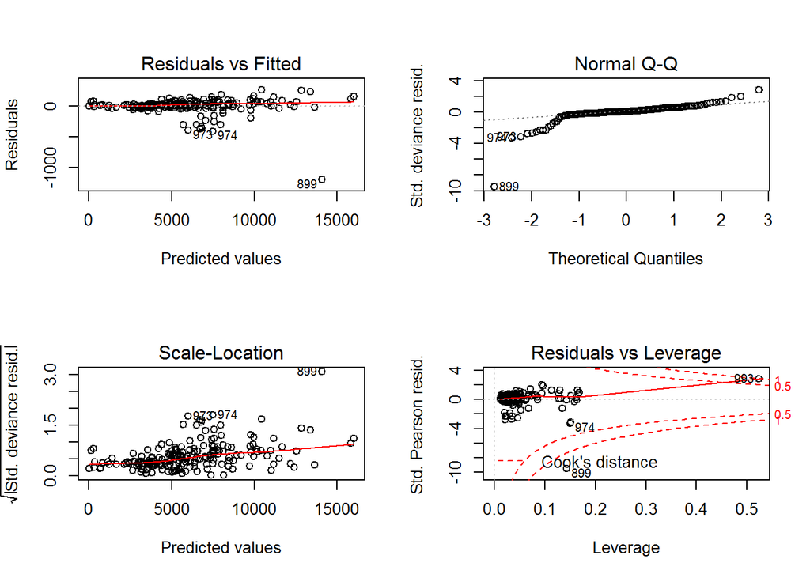

```r
par(mfrow=c(2,2))
plot(fit)
```

**Step 4:** Next, we can then plot the performance of the individual, relative to the most important variables that are making a difference.

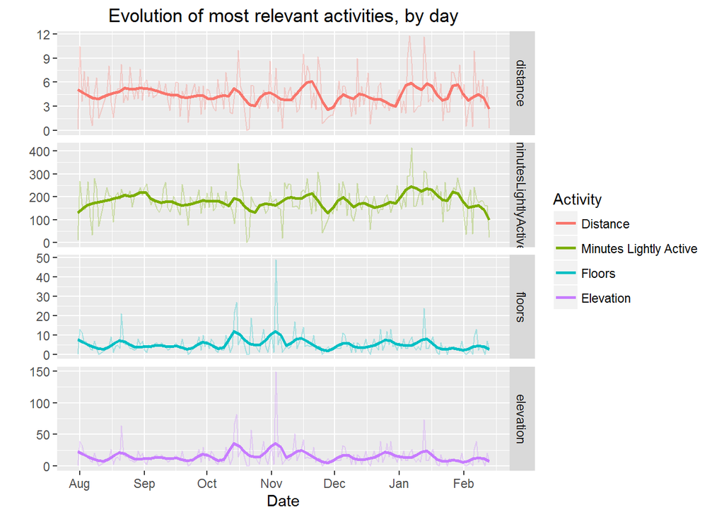

```r
ana$showMostImportantCharts(tsDataFrame = timeseries.frame)
```

**Step 5:** We can also get the prediction on goal performance using the call below.

```r
rows.test <- timeseries.frame[sample(1:191, 1), ]
x <- createDependentVariableFrame(master = rows.test, goal = "steps")
res <- ana$predictGoal(x)
cat(paste("Prediction for the day", ": expected steps = ", round(res)))
```

```
## Prediction for the day : expected steps =  7481
```

## Example 3: FitAnalyzer - Intraday File Analysis

Examples below demonstrate usage scenarios for `FitAnalyzer` for **Intraday analysis**.

**Step 1**: We first need to point to a folder that contains the JSON files for *intraday* file analysis. These files are created by `DataLoader.R`.

We then create a new instance of `FitAnalyzer` passing in the folder and the goal that we want to optimize on. Goals can be the following: a) calories b) steps c) distance d) floors .

The example below uses *calories* as the goal

```r
masterPath <-
    system.file("extdata", "intra-daily-timeseries", package = "fitcoach")
ana <- FitAnalyzer$new("calories")
```

**Step 2:** Next we get the data.frame ready for analysis. Note that this data.frame is cleaned and augmented with additional data elements not present in the JSON file. E.g.: we augment cumulative sum during the day, weekday, weekend, etc.

```r
intra <- ana$getAnalysisFrame(folder = masterPath, analysis.type = "intra.day")
head(intra)
```

```
##         date calories intra.level intra.mets intra.calorie timeseq steps
## 1 2015-12-10     2491           0        150       18.5565       1  5319
## 2 2015-12-10     2491           0        150       18.5565       2  5319
## 3 2015-12-10     2491           0        150       18.5565       3  5319
## 4 2015-12-10     2491           0        150       18.5565       4  5319
## 5 2015-12-10     2491           0        150       18.5565       5  5319
## 6 2015-12-10     2491           0        150       18.5565       6  5319
##   intra.steps floors intra.floors elevation intra.elevation distance
## 1           0      6            0        18               0  3.89512
## 2           0      6            0        18               0  3.89512
## 3           0      6            0        18               0  3.89512
## 4           0      6            0        18               0  3.89512
## 5           0      6            0        18               0  3.89512
## 6           0      6            0        18               0  3.89512
##   intra.distance weekday weekend  slot cumsum.calorie cumsum.steps
## 1              0       5       0 night        18.5565            0
## 2              0       5       0 night        37.1130            0
## 3              0       5       0 night        55.6695            0
## 4              0       5       0 night        74.2260            0
## 5              0       5       0 night        92.7825            0
## 6              0       5       0 night       111.3390            0
##   cumsum.level cumsum.mets cumsum.distance cumsum.floors cumsum.elevation
## 1            0         150               0             0                0
## 2            0         300               0             0                0
## 3            0         450               0             0                0
## 4            0         600               0             0                0
## 5            0         750               0             0                0
## 6            0         900               0             0                0
```

**Step 3:** Next we find the most important variables that are enabling meeting the goals for the person. Note: this call creates a **gbm** model behind the scenes and ranks the variables based on *relative.influence* call to `gbm` model. You can also get the `gbm` fit object to do further analysis.

```r
vars <- ana$findImportantVariables(intra)
vars <- sort(vars, decreasing = TRUE)
vars
```

```
##            steps          weekend         distance           floors
##     1.000000e+00     4.850034e-02     4.112410e-02     2.081519e-02
##          weekday     cumsum.level    cumsum.floors          timeseq
##     9.944454e-03     2.865114e-05     8.797090e-08     8.763791e-08
##     cumsum.steps  cumsum.distance   cumsum.calorie cumsum.elevation
##     4.113028e-08     1.453128e-08     1.427501e-08     7.307049e-09
##    intra.calorie      intra.steps     intra.floors       intra.mets
##     6.349336e-09     9.373329e-10     3.419370e-10     2.913440e-10
##   intra.distance             slot      intra.level        elevation
##     8.783386e-11     6.107080e-11     0.000000e+00     0.000000e+00
##  intra.elevation      cumsum.mets
##     0.000000e+00     0.000000e+00
```

Plot of important variables below.

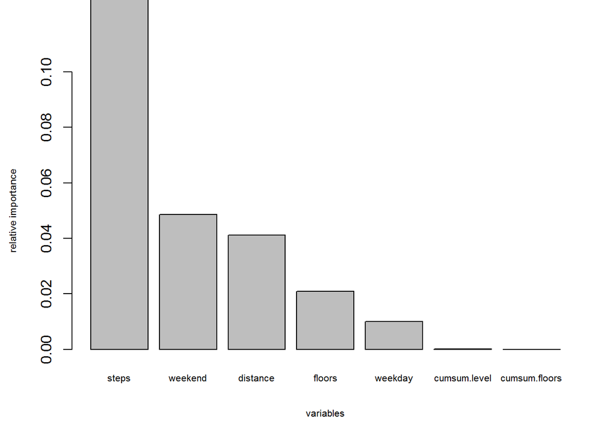

```r
vars.frame <- data.frame(variables = names(vars), values = vars)
vars.frame$lnvalue <- log(vars.frame$values)
vars.frame <- vars.frame[1:7, ]
barplot(vars.frame$value, xlab = "variables", ylab = "relative importance",
        names.arg = vars.frame$variables,
        cex.names = 0.65, cex.lab = 0.65, ylim = c(0.0, 0.1))
```

Summary of GBM model fit below.

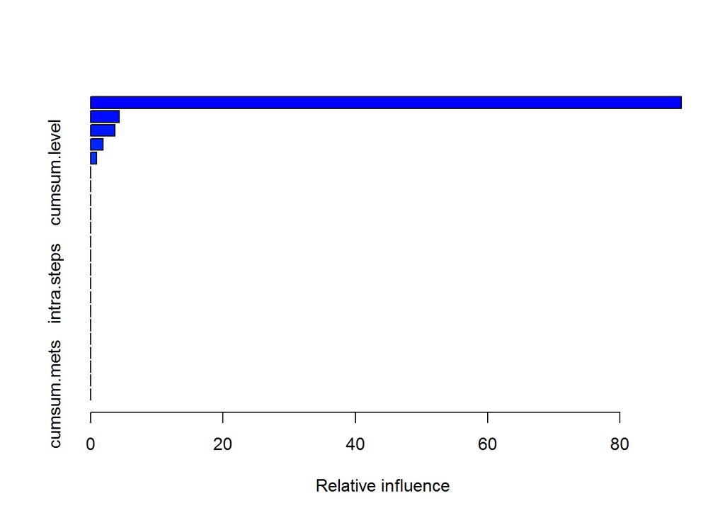

```
##                               var      rel.inf
## steps                       steps 8.925280e+01
## weekend                   weekend 4.328791e+00
## distance                 distance 3.670441e+00
## floors                     floors 1.857814e+00
## weekday                   weekday 8.875704e-01
## cumsum.level         cumsum.level 2.557195e-03
## cumsum.floors       cumsum.floors 7.851649e-06
## timeseq                   timeseq 7.821929e-06
## cumsum.steps         cumsum.steps 3.670992e-06
## cumsum.distance   cumsum.distance 1.296958e-06
## cumsum.calorie     cumsum.calorie 1.274084e-06
## cumsum.elevation cumsum.elevation 6.521746e-07
## intra.calorie       intra.calorie 5.666960e-07
## intra.steps           intra.steps 8.365959e-08
## intra.floors         intra.floors 3.051884e-08
## intra.mets             intra.mets 2.600326e-08
## intra.distance     intra.distance 7.839418e-09
## slot                         slot 5.450740e-09
## intra.level           intra.level 0.000000e+00
## elevation               elevation 0.000000e+00
## intra.elevation   intra.elevation 0.000000e+00
## cumsum.mets           cumsum.mets 0.000000e+00
```

```r
fit <- ana$getFit()
summary(fit)
```

**Step 4:** Next we can then plot the performance of the individual relative to the most important variables that are making a difference. For the 4 most important variables, the average value for every 15 min of a day is plotted, along with the moving average (using `geom_smooth` from `ggplot2`).

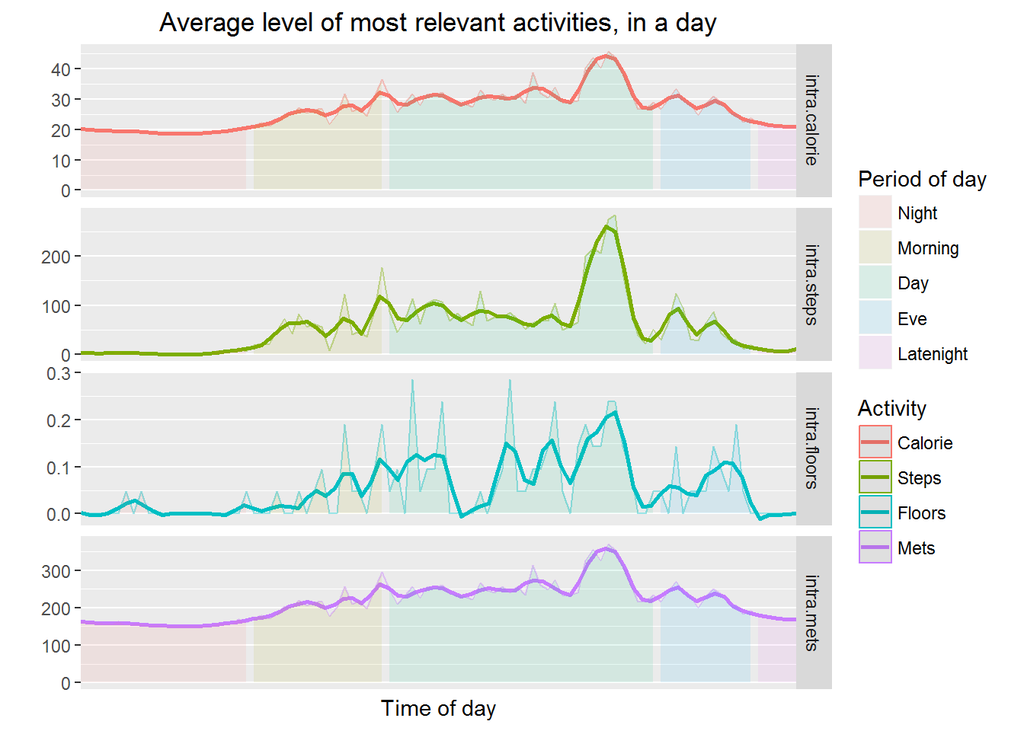

```r
ana$showMostImportantCharts(tsDataFrame = intra)
```

**Step 5:** We can also get the prediction on goal performance using the call below.

```r
rows.test <- intra[sample(1:191, 1), ] # Take any random input for test
res <- ana$predictGoal(rows.test)
cat(paste("Prediction for the day", ": expected calories =", round(res)))
```

```
## Prediction for the day : expected calories = 2517
```

## Example 4: FitUtil - Illustration for usage of FitUtil functions

Approach to get a clean data.frame from JSON files.

```r
# masterPath is the folder containing JSON files
masterPath <- system.file("extdata", "daily-time-series", package = "fitcoach")

# Create the data.frame. This is not cleaned
master <- createTsMasterFrame(masterPath)

# Identify and Mark rows that are valid. i.e distance for the day >0
master <- markValidRows(master)

# Filter Valid rows only
master <- master[master$valid == TRUE, ]

# Augment data with additional information. Eg: weekday information
master <- augmentData(master)
head(master)
```

```
##           date calories caloriesBMR steps distance floors elevation
## 898 2015-07-31     1867        1759   195  0.14062      0         0
## 899 2015-08-01     3245        1758 12866 10.44119     13        39
## 900 2015-08-02     2867        1758  5023  3.65184     11        33
## 901 2015-08-03     2982        1758 10112  7.35157      6        18
## 902 2015-08-04     2734        1758  5725  4.16213      7        21
## 903 2015-08-05     3012        1758  9155  6.72913      5        15
##     minutesSedentary minutesLightlyActive minutesFairlyActive
## 898              205                   10                   0
## 899              672                  269                   5
## 900              691                  168                  25
## 901             1161                  143                   5
## 902              836                  150                  18
## 903              640                  267                  16
##     minutesVeryActive activityCalories valid   weekday weekend
## 898                 0               51  TRUE    Friday   FALSE
## 899                37             1600  TRUE  Saturday    TRUE
## 900                35             1196  TRUE    Sunday    TRUE
## 901                66             1253  TRUE    Monday   FALSE
## 902                23              961  TRUE   Tuesday   FALSE
## 903                16             1372  TRUE Wednesday   FALSE
```